# LoD Studies: Experimental Design and Analysis

28 August 2022

# 1 Abstract

In this vignette we look at experimental design and analysis issues around LoD estimation. In particular, we examine the *minimal experiment design* for the probit appproach to the evaluation of the limit of detection from CLSI document EP17-A2 [1]. A question of interest is how to estimate the SE of an LoD estimate. For LoD estimates derived from a fitted probit or logistic model, the CRAN R package `investr` (inverse estimation, or calibration) produces LoD CIs based on established mathematical theory. We compare these estimates of standard errors to Monte Carlo simulation standard deviations.

We also consider an alternative to the probit modeling approach for estimating the LoD. The motivation is the following:

- Nowhere in the probit modeling approach to LoD estimation is the linear predictor that is part of the probit model used directly - the estimated coefficients are never examined nor used directly.
- The only purpose that the model serves is to provide an estimated hit-rate or detection fraction at a fixed dose, or `dose` in this case. The dose of interest is the LD95 dose where the hit-rate (first) exceeds 95%.
- Whereas a paremetric model such as the probit model could be helpful in finding the LD95 dose, once this dose is known, or approximately known, the probit model is no longer useful.
- For the purpose of establishing the LD95 dose level, we argue that collecting data at the wide range of dosages necessary to obtain a reliable probit fit is inefficient. We are better off collecting detection preformance characteristics at a few points near the LD95 dose.

In the last section of this vignette we show how the LD95 value can be accurately estimated from detection data at a few points near the LD95 value.

## 1.1 Open Questions

# 2 Outline

- Section 3 descibes the probit model and how it is used to estimate a Limit of Detection (LoD) for a test.
- In Section 4 we analyze the data from the probit examples from Appendix C from CLSI document EP17-A2 [1].
  - by reproducing the results from CLSI document EP17-A2 we establish the validity of some software tools that could be used for LoD studies in accordance to the CLSI document EP17-A2 guidance.
- In Section 5 we look at variability in the estimated LoD based on probit fits to some simaluated data.
- In Section 6 we look at the performance of an an alternative LoD estimate based on detection data collected near the LoD.
- References are listed in Section 7.

The remainder of the sections are Appendices with reference material and additional data explorations.

Nomenclature:

- `dose` and `dose` are used interchangeably throughout.
- `prob` and `hit rate` are used interchangeably throughout.
- LoD = Limit of Detection.
- LD95 = Dose for which the hit rate is 0.95. ie. the LoD when the target hit rate is 95%.
- As dose values of interest are very small, we will use `dose * 1e6` in some analyses with loss of generality. ie. a dose value of 0.03% will be representd by a value of 300.

# 3 The Probit Model for LoD estimation

The probit model for success rate, coded as $Y=1$, given a covariate design $X$ is specified by the following equation:

$$\begin{equation}
P(Y=1 | X) = \Phi( X \cdot B)
\tag{1}
\end{equation}$$

In the simple case of a single covariate, this reduces to:

$$\begin{equation}
P(Y=1 | x) = \Phi( \alpha + \beta \cdot x )
\tag{2}
\end{equation}$$

To find $x$ correspoding to a given probability of success $p$:
$$\begin{equation}
x = \frac{\Phi^{-1}(p) - \alpha}{\beta}
\tag{3}
\end{equation}$$

The LoD is estimated as the value of $x$ corresponding to a given hit rate or probability of success $p$. The target hit rate will vary from application to application. In the context of a molecular diagnostic test that aims to detect cancer, the targeted hit rate may be 95%, for example, and $x$ may be an indicator of tumor load. The limit of detection is then the estimated sample tumor load for which the test is expected to detect 95% of the cases.

An LoD value can be estimated from a fitted probit model using basic R functions.

```
inv_probit <- function(p, m) (qnorm(p) - coef(m)[1])/coef(m)[2]

probit_fit <- glm(cbind(Detected, Total-Detected) ~ log10(Conc),
           binomial(link = "probit"), data=data_frm)

LD95 <- 10^inv_probit(0.95, m=probit_fit)
```

Similar functions can be invoked to get estimates of LoD based on a fitted logit model.

## 3.1 The interpretation of the estimated coefficients

To interpert the estimated coefficients in Equation (2) one needs to visualize the shape of the cumulative normal distribution, $\Phi(x)$, and realize how the coefficients, $\alpha$ and $\beta$, will transform the domain, $x$, of the transformation, $\Phi$.

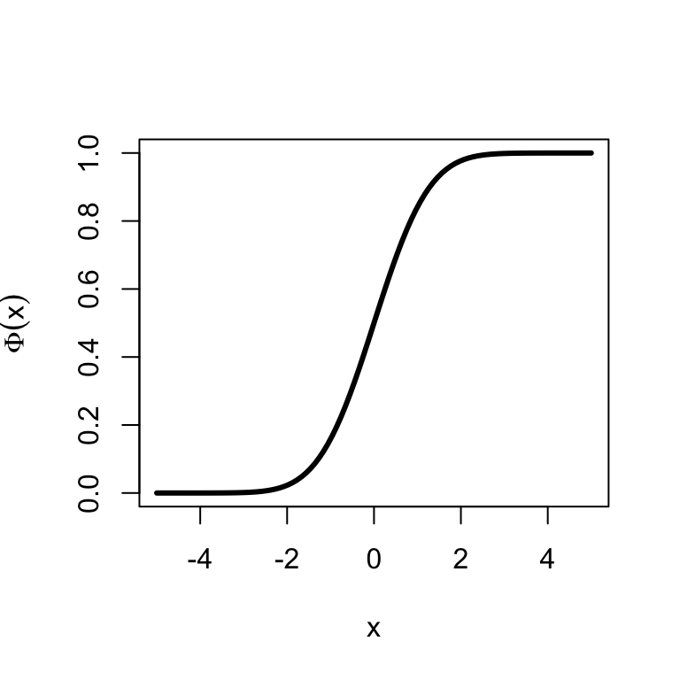

Figure 1: Cumulative Normal Distribution

```r
x_vec <- seq(-5, 5, length.out = 100)
plot(x=x_vec, y=pnorm(x_vec), xlab='x',
ylab=expression(Phi(x)), type='l', lwd=3)
```

- $\Phi(x)$ is close to zero for x < -3, and close to 1 when x > 3.
- In the probit fit, $\Phi( \alpha + \beta \cdot x )$, the linear transformation, $\alpha + \beta \cdot x$, shifts and rescales the abscissa, or the x-axis.
- Changing either $\alpha$ or $\beta$ will affect when, as a function of x, the transformed abscissa will reach -3 and the corresponding transformed values, $\Phi( \alpha + \beta \cdot x )$, begin to rise above zero.
- How fast, as a function of x, the values of $\Phi( \alpha + \beta \cdot x )$ go from 0 to 1, what we can think of as the “slope” in the probit fit, only depends on $\beta$.

## 3.2 Note on confidence intervals for the LoD

We note that the *confidence interval* for the estimated predictor value that corresponds to a specified response value, ie. the LoD, is different and cannot be derived from the confidence interval for fitted values (ie. the expected response at any given point in the predictor space) or the confidence interval for a predicted value (ie. a predicted response at any given point).  
This critically important distinction is not made in EP17-A2 [1]. In fact confidence intervals for the LoD estimates and confidence bands for the fits are mentionned in the same paragraph without emphasizing that the two are distinct entities. When we repeat the analysis of the *EP17-A2 Probit Example* in the next section we add confidence interval estimates for the LoD to the results, but we omit the confidence bounds around the fit as these cannot be used to judge the uncertainty in the estimated LoD, which is our primary concern.

# 4 EP17-A2 Probit Example

Assemble data frame as in EP17-A2 Appendix C [1].

```r
example_data_frm <- as.data.frame(rbind(

c(Conc = 0.000, Lot=1, Total=22, Detected=0),   # Conc = 0 is not used for probit fits!!!
c(Conc = 0.000, Lot=2, Total=22, Detected=0),
c(Conc = 0.000, Lot=3, Total=22, Detected=0),

c(Conc = 0.006, Lot=1, Total=30, Detected=11),
c(Conc = 0.006, Lot=2, Total=30, Detected=12),
c(Conc = 0.006, Lot=3, Total=34, Detected=22),

c(Conc = 0.014, Lot=1, Total=30, Detected=15),
c(Conc = 0.014, Lot=2, Total=30, Detected=22),
c(Conc = 0.014, Lot=3, Total=34, Detected=31),

c(Conc = 0.025, Lot=1, Total=32, Detected=23),
c(Conc = 0.025, Lot=2, Total=32, Detected=28),
c(Conc = 0.025, Lot=3, Total=32, Detected=27),

c(Conc = 0.050, Lot=1, Total=32, Detected=29),
c(Conc = 0.050, Lot=2, Total=32, Detected=32),
c(Conc = 0.050, Lot=3, Total=32, Detected=32),

c(Conc = 0.150, Lot=1, Total=32, Detected=32),
c(Conc = 0.150, Lot=2, Total=32, Detected=32),
c(Conc = 0.150, Lot=3, Total=32, Detected=32),

c(Conc = 0.300, Lot=1, Total=32, Detected=32),
c(Conc = 0.300, Lot=2, Total=32, Detected=32),
c(Conc = 0.300, Lot=3, Total=32, Detected=32),

c(Conc = 0.500, Lot=1, Total=32, Detected=32),
c(Conc = 0.500, Lot=2, Total=32, Detected=32),
c(Conc = 0.500, Lot=3, Total=32, Detected=32)
)
)

example_data_frm$hitRate <- with(example_data_frm,
round(Detected/Total, 3))
```

- This example is for a molecular diagnostics test for which the **limit of blank** (LoB) equals zero. Data were collected using three lots of reagent to establish the limit of detection (LoD) by probit analysis for a microbiology test done on bacterial DNA. A single patient sample is used to simplify this example, rather than the minimum of three as required by the protocol. A dilution series of five measurand concentrations was prepared from the sample and a set of measurement replicates were made for each dilution using three reagent lots. Also, a negative pool was prepared from native specimens and tested with replication to demonstrate that LoB = 0. The number of positive results observed, total number of measurements made, are summarized in Table 1

```r
knitr::kable(example_data_frm %>%
  dplyr::filter(Conc %in% c(0, 0.025, 0.05, 0.15, 0.3, 0.5)),
   caption='Planned Dilutions Data') %>%
kableExtra::kable_styling(full_width = F)
```

Table 1: Planned Dilutions Data

| Conc | Lot | Total | Detected | hitRate |
| --- | --- | --- | --- | --- |
| 0.000 | 1 | 22 | 0 | 0.000 |
| 0.000 | 2 | 22 | 0 | 0.000 |
| 0.000 | 3 | 22 | 0 | 0.000 |
| 0.025 | 1 | 32 | 23 | 0.719 |
| 0.025 | 2 | 32 | 28 | 0.875 |
| 0.025 | 3 | 32 | 27 | 0.844 |
| 0.050 | 1 | 32 | 29 | 0.906 |
| 0.050 | 2 | 32 | 32 | 1.000 |
| 0.050 | 3 | 32 | 32 | 1.000 |
| 0.150 | 1 | 32 | 32 | 1.000 |
| 0.150 | 2 | 32 | 32 | 1.000 |
| 0.150 | 3 | 32 | 32 | 1.000 |
| 0.300 | 1 | 32 | 32 | 1.000 |
| 0.300 | 2 | 32 | 32 | 1.000 |
| 0.300 | 3 | 32 | 32 | 1.000 |
| 0.500 | 1 | 32 | 32 | 1.000 |
| 0.500 | 2 | 32 | 32 | 1.000 |
| 0.500 | 3 | 32 | 32 | 1.000 |

- The results from these planned concentration levels show only one or two nonzero levels with a hit rate less than 1.000. Such data do not allow for fitting probit models. For this reason, two additional, lower concentration levels were tested and added to the initial data. The results are shown in Table 2

```r
knitr::kable(example_data_frm %>%
  dplyr::filter(Conc %in% c(0.006, 0.014)),
   caption='Additonal Dilutions Data') %>%
kableExtra::kable_styling(full_width = F)
```

Table 2: Additonal Dilutions Data

| Conc | Lot | Total | Detected | hitRate |
| --- | --- | --- | --- | --- |
| 0.006 | 1 | 30 | 11 | 0.367 |
| 0.006 | 2 | 30 | 12 | 0.400 |
| 0.006 | 3 | 34 | 22 | 0.647 |
| 0.014 | 1 | 30 | 15 | 0.500 |
| 0.014 | 2 | 30 | 22 | 0.733 |
| 0.014 | 3 | 34 | 31 | 0.912 |

- The data were reanalyzed using software for probit analysis. This approach allows use of all data obtained with low level samples and provides associated confidence intervals for the LoD estimates. No lack of fit of the probit models was detected, using both a **Pearson chi-square test** and a **log-likelihood ratio chi-square test**, which allowed for prediction of the LoD. The results are summarized in Table C3 and the graphs of fitted probit models, including 95% confidence bands for the respective fits, are shown in Figures C1, C2, and C3.

## 4.1 EP17-A2 Example - Probit Fits

In this section we fit probit models to the example data and estimate the LoD for each Lot. We also include 90% confidence intervals around the LoD estiamates.

```r
inv_probit <- function(p, m) (qnorm(p) - coef(m)[1])/coef(m)[2]
get_prob <- function(x, Beta) pnorm(Beta[1] + x*Beta[2])

############################################
#plot_fit_probit(example_data_frm %>% dplyr::filter(Conc > 0 & Lot==1), lot1_fit, Title='Lot 1')

DEBUG <- function() {

data_frm <- example_data_frm %>% dplyr::filter(Conc > 0 & Lot==1)
fit <-  lot1_fit
Target=0.95
Conf=0.90
Title='Lot 1'

}#DEBUG

plot_fit_probit <- function(data_frm, fit, Target=0.95, Conf=0.90, Title=NULL){
 # Target of Detection/Hit rate for LoD
 if(!(Target > 0  & Target < 1))
 stop("Target should be in (0,1)")

 if(!(Conf > 0  & Conf < 1))
 stop("Conf should be in (0,1)")

 # Should dalso validate data_frm and fit ...

 # plot fit on probit scale
 conc_range <- range(log10(example_data_frm$Conc+.001))

 # model on probit scale
 model_frm  <- data.frame(
     x = seq(conc_range[1], conc_range[2], length.out=10000)) %>%
     dplyr::mutate( y = pnorm(coef(fit)[1] +  x*coef(fit)[2]))

 with(model_frm,
   plot(x=x, y=y, type='n', col='green', xlab='', ylab='Prob Detected',
        xlim=conc_range, log='', ylim=c(0, 1.1), xaxt='n')
 )
 axis(side=1, at=log10(c(0.001, .01, .1, 1)), labels=c(0.001, .01, .1, 1))
 abline(v=log10(c(0.001, .01, .1, 1)), col='grey')
 abline(h=seq(.1, .9, by=.1), col='grey')
 mtext(side=1, 'Conc', line=4)

 with(model_frm,  points(x=x, y=y, type='l', col='black', lwd=3))
 # Draw points x vs y
 with(data_frm, points(log10(Conc), hitRate, pch=19) )

 if(!is.null(Title)) title(Title)

 # Add dotted line for P=Target
 x_pTarget <- inv_probit(Target, fit)
 segments(x0=log10(.001), x1=x_pTarget, y0=Target, y1=Target, col='red', lty=2)
 segments(x0=x_pTarget, x1=x_pTarget, y0=Target, y1=0, col='red', lty=2)

 # Pearson chi2 - NOT USED
 pearson_chi2 <- sum(residuals(fit, type = "pearson")^2)

 # Add LoD by investr::invest
 tryCatch(
 LDTarget_invest <- as.numeric(unlist(investr::invest(fit, y0=Target, level=Conf, interval="Wald"))[1:3])
,  error = function(e) { LDTarget_invest <<- rep(NA,3)}
)

 # Recall plot is on conc scale
 rug(log10(LDTarget_invest), ticksize = 0.06, side = 1, lwd = 1.0, col='blue')

 LoD_text <-  sprintf("%s%s%s%s",
 "LoD ", round(100*Target),': ', formatC(10^x_pTarget, format = "f", digits = 3))
 LoD_text <- sprintf("%s\n(CI: %s - %s)", LoD_text,
                formatC((LDTarget_invest[2]), format = "f", digits = 3),
                formatC((LDTarget_invest[3]), format = "f", digits = 3))

 text(x=min(model_frm$x), y=1.0, pos=4, labels=LoD_text, col='blue')

 list(Target = Target, Conf = Conf, invest = LDTarget_invest)

}
```

### Lot 1

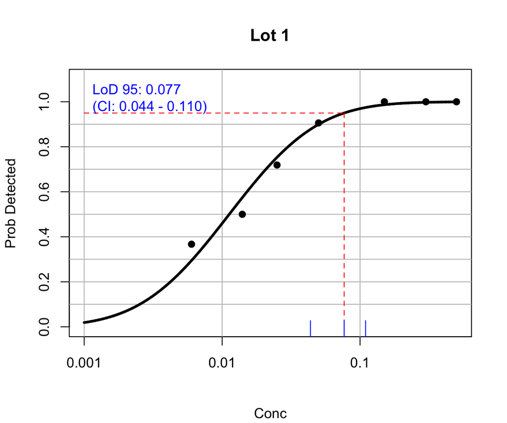

Figure 2: Example Data Probit Fit - Lot 1

```r
lot1_fit <- glm(cbind(Detected, Total-Detected) ~ log10(Conc),
 binomial(link = "probit"),
 data = example_data_frm %>% dplyr::filter(Conc > 0 & Lot==1))

lot1_LD95 <- 10^inv_probit(p=0.95, m=lot1_fit)

lot1_LD95_res  <-
plot_fit_probit(example_data_frm %>% dplyr::filter(Conc > 0 & Lot==1), lot1_fit, Title='Lot 1')
```

### Lot 2

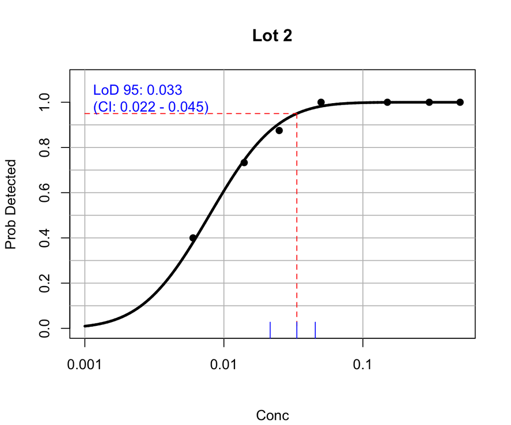

Figure 3: Example Data Probit Fit - Lot 2

```r
lot2_fit <- glm(cbind(Detected, Total-Detected) ~ log10(Conc),
 binomial(link = "probit"),
 data = example_data_frm %>% dplyr::filter(Conc > 0 & Lot==2))

lot2_LD95 <- 10^inv_probit(p=0.95, m=lot2_fit)

lot2_LD95_red <-
plot_fit_probit(example_data_frm %>% dplyr::filter(Conc > 0 & Lot==2), lot2_fit, Title='Lot 2')
```

### Lot 3

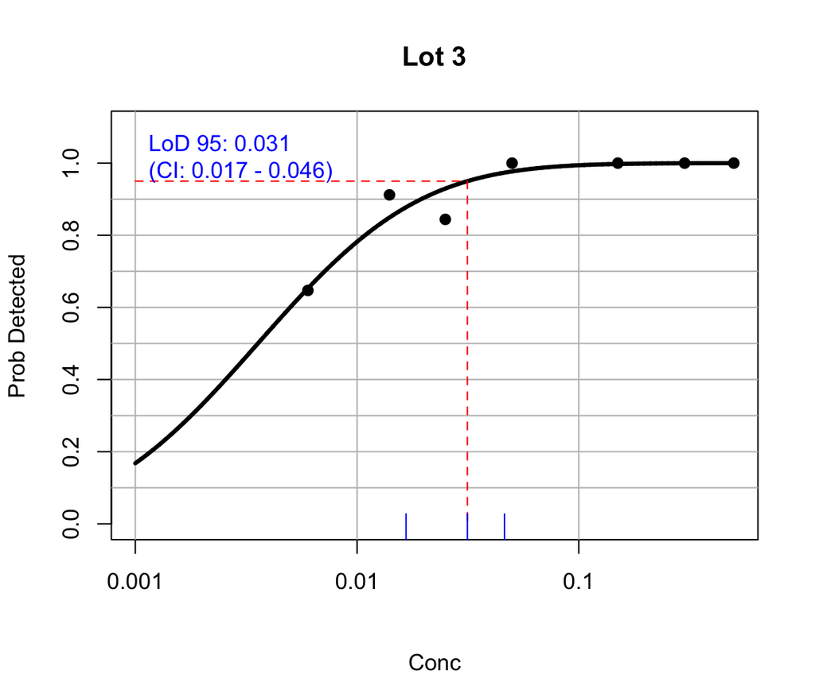

Figure 4: Example Data Probit Fit - Lot 3

```r
lot3_fit <- glm(cbind(Detected, Total-Detected) ~ log10(Conc),
 binomial(link = "probit"),
 data = example_data_frm %>% dplyr::filter(Conc > 0 & Lot==3))

lot3_LD95 <- 10^inv_probit(p=0.95, m=lot3_fit)

#cat("Lot 3 LD95 =", round(lot3_LD95, 3), '\n')

lot3_LD95_red <-
plot_fit_probit(example_data_frm %>% dplyr::filter(Conc > 0 & Lot==3), lot3_fit, Title='Lot 3')
```

# 5 Variability of LoD Estimate

```r
full_probit_design <- data.frame(
dose=c(185, 20, 230, 280, 310, 350, 400),
prob=c(0.1, .2, .5, .9, .98, .99, 1 ))


# Print design
#knitr::kable(full_probit_design, caption="Simulation Design Parameters")

knitr::kable(
t(full_probit_design %>% dplyr::mutate(dose=round(dose))),
caption="Simulation Design Parameters (dose is conc * 1e6)"
) %>%
kableExtra::kable_styling(full_width = F)
```

Table 3: Simulation Design Parameters (dose is conc * 1e6)

| dose | 185.0 | 20.0 | 230.0 | 280.0 | 310.00 | 350.00 | 400 |
| --- | --- | --- | --- | --- | --- | --- | --- |
| prob | 0.1 | 0.2 | 0.5 | 0.9 | 0.98 | 0.99 | 1 |

```r
data_frm <-
do.call('rbind', lapply(1:nrow(full_probit_design), function(RR)
data.frame(dose=full_probit_design[RR, 'dose'],
detected = rbinom(rep(1, 20), size=1, prob=full_probit_design[RR,  'prob']))))

full_probit_fit <- glm(detected ~ dose, data=data_frm,
   binomial(link = "probit"))
```

```r
# define utility functions for simulations

# From hit-rate and model, get dose
# - used to get design points at fixed prob values
# - also used to read out LoD from fitted model
inv_probit <- function(p, m) (qnorm(p) - coef(m)[1])/coef(m)[2]

# Given a design (dose, prob) and nSamp
# generate nSamp rbinom variates detected in (0,1)
# with P(detected) = prob
sim_data <- function (design, nSamp=20) do.call('rbind', lapply(1:nrow(design), function(RR){
    dose <- design[RR, 'dose']
    prob <- design[RR, 'prob']
    data.frame(dose=dose, detected = rbinom(n=nSamp, size=1, p=prob))
   }))


####################################################
plot_model <- function(design, model, Line=T, Points=F, Col='green',
  New=T, Xlab=T, invLink=pnorm, Ylim=c(0,1.1), Xlim=NULL){
 # for New = T
 #  initialize plotting figure for parameter model
 #  with desing points as in parameter design
 #  optionnally add model curve to plot
 # New = F
 #  is used to simply add the model curve and design points
 #  to an already initialized figure
 #---------------------------------------------------

 dose_RANGE <- range(design$dose)
 model_frm <- data.frame(
    x = seq(dose_RANGE[1], dose_RANGE[2], length.out=10000)) %>%
    dplyr::mutate( y = invLink(coef(model)[1] +  x*coef(model)[2]))

 if(is.null(Xlim)) Xlim <- dose_RANGE

 if(New) {
 with(model_frm,
  plot(x=x, y=y, type='n', col='green', xlab='', ylab='Prob Detected',
       xlim=Xlim, log='x', ylim=Ylim, xaxt='n')
 )
 if(Xlab) mtext(side=1, 'dose', line=4)
 # Add axis
 axis(side=1, at=design$dose, labels=round(design$dose), las=1)
 }

 # add model line
 if(Line)
 with(model_frm,  points(x=x, y=y, type='l', col=Col, lwd=3))

 # add model points
 if(Points)
 with(design,
 points(x=dose, y=invLink(coef(model)[1] +  dose*coef(model)[2]),
   pch=16))
}

######################################
get_probit_lod <- function(data_frm, Target=0.95, Conf=0.90, Plotit=F, Col='blue') {

 glm_fit <- glm(detected ~ dose, data=data_frm, binomial(link = "probit"))

 # plot
if(Plotit) {
 dose_RANGE <- range(data_frm$dose)
 sim_fit_frm <- data.frame(
   x = seq(dose_RANGE[1], dose_RANGE[2], length.out=10000)) %>%
   dplyr::mutate( y = pnorm(coef(glm_fit)[1] +  x*coef(glm_fit)[2]))
 with(sim_fit_frm, points(x=x, y=y, type='l', col=Col))
}

 # return dose at Target
 #LD95 <- inv_probit(Target, glm_fit)
 #LD95

 tryCatch(
 LDTarget_invest <- as.numeric(unlist(investr::invest(glm_fit, y0=Target, level=Conf, interval='Wald'))[1:4])
,  error = function(e) { LDTarget_invest <<- rep(NA,4)}
)
 names(LDTarget_invest) <- c('est', 'lo', 'hi', 'se')
 # DEBUG
 #(LDTarget_invest[2:3] - LDTarget_invest[1])/qnorm(p= 1 - (1-Conf)/2)

 # return c('est', 'lo', 'hi', 'se')
 LDTarget_invest
}
```

## 5.1 LoD Estimate Variability

We simulate experiments by generating binomially distributed variates around a fixed model curve for all design points. ie. We are simulating an entire data collection exercise to get a sense of the variability in estimated LoDs. One question of interest is how the standard error that is derived from calibration theory - the se produced by the investr::invest function - relates to the empirically determined standard deviation of the estimated LoD computed from the simulated data.

To examine the effect of sample size we will consider 3 data sets having N = 20, 40 and 60 points are each design points. For each of these conditions we will generate 30 simulated datasets and perform the LoD analysis on each dataset giving rise to 30 estimated LoDs and inverse regression standard errors. From the 30 estimated LoDs we can compute an SD and compare that to the distribution of estiamted SEs.

### N = 20

Generate and plot 30 instances of probit fits to full full_probit_design with N = 20 at each design point. The total number of observations in each simulated data set is 140.

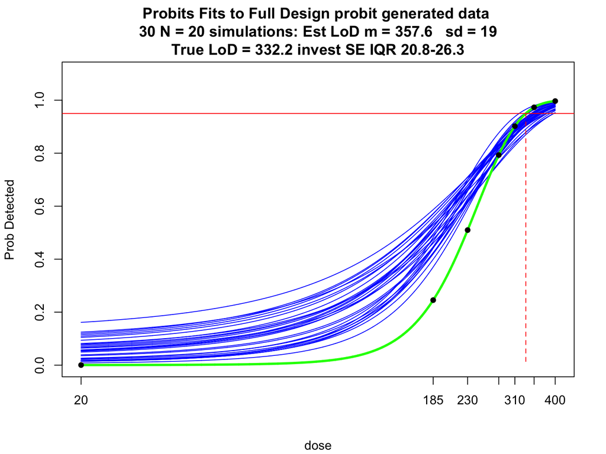

Figure 5: Simulate Full Design; 30 x 20

```r
MODEL <- "Full Design"
fit_design <- full_probit_design

set.seed(12379)

# initialize plot
plot_model(full_probit_design, model=full_probit_fit, Line=F, Points=F)

# get true_lod
Target <- 0.95 # Targeted hit rate for LoD
true_lod <- inv_probit(Target, full_probit_fit)

# Get REP estimates of LoD for MODEL
N20_lod_mtx <- do.call('rbind', lapply(1:REP, function(JJ) {
 sim_frm <- sim_data(fit_design, nSamp=NSAMP)
 get_probit_lod(sim_frm, Plotit=T)
}))


### THIS NEEDS TO BE HANDLED BETTER
N20_lod_mtx <- N20_lod_mtx[!(rowSums(is.na(N20_lod_mtx) > 0)),]

# summarize results in title
title(paste("Probits Fits to", MODEL, "probit generated data",
"\n", REP, 'N =', NSAMP, "simulations:",
"Est LoD m =", round(mean(N20_lod_mtx[,1]),1), "  sd =", round(sd(N20_lod_mtx[,1]),1),
"\nTrue LoD =", round(true_lod,1),
 "invest SE IQR", paste(round(quantile(N20_lod_mtx[,4], prob=c(1,3)/4),1),collapse='-')))

# add model line and design points for fit
plot_model(full_probit_design, model=full_probit_fit, New=F, Line=T, Points=F)
plot_model(fit_design, model=full_probit_fit, New=F, Line=F, Points=T)

# Add dotted line for P=Target
x_pTarget <- inv_probit(Target, full_probit_fit)
segments(x0=x_pTarget, x1=x_pTarget, y0=Target, y1=0, col='red', lty=2)
#segments(x0=1e-7, x1=x_pTarget, y0=Target, y1=Target, col='red', lty=2)
abline(h=Target, col='red')
```

### N = 40

Generate and plot 30 instances of probit fits to full full_probit_design with N = 40 at each design point. The total number of observations in each simulated data set is 280.

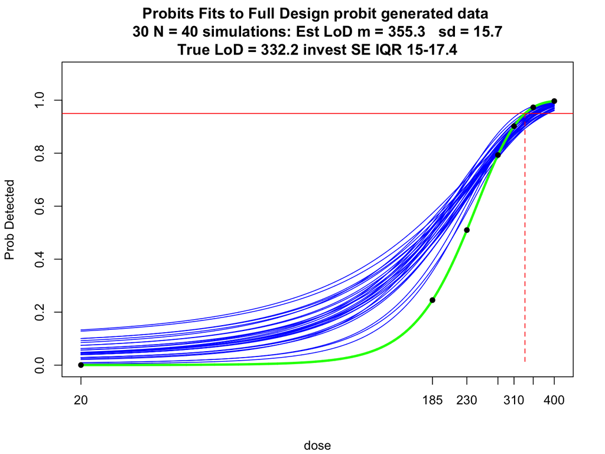

Figure 6: Simulate Full Design; 30 x 40

```r
MODEL <- "Full Design"
fit_design <- full_probit_design

set.seed(12379)

# initialize plot
plot_model(full_probit_design, model=full_probit_fit, Line=F, Points=F)

# get true_lod
Target <- 0.95 # Targeted hit rate for LoD
true_lod <- inv_probit(Target, full_probit_fit)

# Get REP estimates of LoD for MODEL
N40_lod_mtx <- do.call('rbind', lapply(1:REP, function(JJ) {
 sim_frm <- sim_data(fit_design, nSamp=NSAMP)
 get_probit_lod(sim_frm, Plotit=T)
}))

### THIS NEEDS TO BE HANDLED BETTER
N40_lod_mtx <- N40_lod_mtx[!(rowSums(is.na(N40_lod_mtx) > 0)),]

# summarize results in title
title(paste("Probits Fits to", MODEL, "probit generated data",
"\n", REP, 'N =', NSAMP, "simulations:",
"Est LoD m =", round(mean( N40_lod_mtx[,1]),1), "  sd =", round(sd(N40_lod_mtx[,1]),1),
"\nTrue LoD =", round(true_lod,1),
 "invest SE IQR", paste(round(quantile(N40_lod_mtx[,4], prob=c(1,3)/4),1),collapse='-')))

# add model line and design points for fit
plot_model(full_probit_design, model=full_probit_fit, New=F, Line=T, Points=F)
plot_model(fit_design, model=full_probit_fit, New=F, Line=F, Points=T)

# Add dotted line for P=Target
x_pTarget <- inv_probit(Target, full_probit_fit)
segments(x0=x_pTarget, x1=x_pTarget, y0=Target, y1=0, col='red', lty=2)
#segments(x0=1e-7, x1=x_pTarget, y0=Target, y1=Target, col='red', lty=2)
abline(h=Target, col='red')
```

### N = 60

Generate and plot 30 instances of probit fits to full full_probit_design with N = 60 at each design point. The total number of observations in each simulated data set is 420.

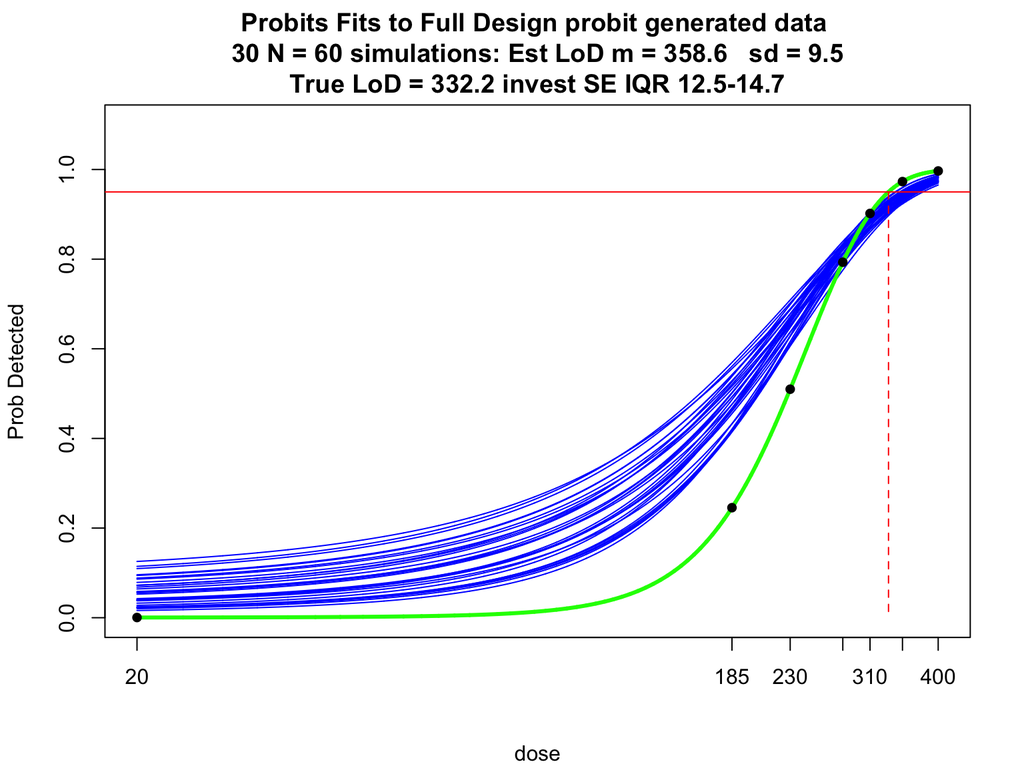

Figure 7: Simulate Full Design; 30 x 60

```r
MODEL <- "Full Design"
fit_design <- full_probit_design

set.seed(12379)

# initialize plot
plot_model(full_probit_design, model=full_probit_fit, Line=F, Points=F)

# get true_lod
Target <- 0.95 # Targeted hit rate for LoD
true_lod <- inv_probit(Target, full_probit_fit)

# Get REP estimates of LoD for MODEL
N60_lod_mtx <- do.call('rbind', lapply(1:REP, function(JJ) {
 sim_frm <- sim_data(fit_design, nSamp=NSAMP)
 get_probit_lod(sim_frm, Plotit=T)
}))

### THIS NEEDS TO BE HANDLED BETTER
N60_lod_mtx <- N60_lod_mtx[!(rowSums(is.na(N60_lod_mtx) > 0)),]


# summarize results in title
title(paste("Probits Fits to", MODEL, "probit generated data",
"\n", REP, 'N =', NSAMP, "simulations:",
"Est LoD m =", round(mean(N60_lod_mtx[,1]),1), "  sd =", round(sd(N60_lod_mtx[,1]),1),
"\nTrue LoD =", round(true_lod,1),
 "invest SE IQR", paste(round(quantile(N60_lod_mtx[,4], prob=c(1,3)/4),1),collapse='-')))

# add model line and design points for fit
plot_model(full_probit_design, model=full_probit_fit, New=F, Line=T, Points=F)
plot_model(fit_design, model=full_probit_fit, New=F, Line=F, Points=T)

# Add dotted line for P=Target
x_pTarget <- inv_probit(Target, full_probit_fit)
segments(x0=x_pTarget, x1=x_pTarget, y0=Target, y1=0, col='red', lty=2)
#segments(x0=1e-7, x1=x_pTarget, y0=Target, y1=Target, col='red', lty=2)
abline(h=Target, col='red')
```

## 5.2 LoD Estimate Variability - Summary

```r
lod_est_var_mtx <-
rbind(
c(N = 20,
  lod_mean = round(mean(N20_lod_mtx[,1]),1),
  lod_sd = round(sd(N20_lod_mtx[,1]),1),
  lod_cv = round(100 * sd(N20_lod_mtx[,1])/mean(N20_lod_mtx[,1]), 1),
  invest_se_mean = round(mean(N20_lod_mtx[,4]),1)),
c(N = 40,
  lod_mean = round(mean(N40_lod_mtx[,1]),1),
  lod_sd = round(sd(N40_lod_mtx[,1]),1),
  lod_cv = round(100 * sd(N40_lod_mtx[,1])/mean(N40_lod_mtx[,1]), 1),
  invest_se_mean = round(mean(N40_lod_mtx[,4]),1)),
c(N = 60,
  lod_mean = round(mean(N60_lod_mtx[,1]),1),
  lod_sd = round(sd(N60_lod_mtx[,1]),1),
  lod_cv = round(100 * sd(N60_lod_mtx[,1])/mean(N60_lod_mtx[,1]), 1),
  invest_se_mean = round(mean(N60_lod_mtx[,4]),1)))

knitr::kable(
lod_est_var_mtx,
caption=paste("LoD Estimate Variability - Summary: True LoD =",round(true_lod,1))
) %>%
kableExtra::kable_styling(full_width = F)
```

Table 4: LoD Estimate Variability - Summary: True LoD = 332.2

| N | lod_mean | lod_sd | lod_cv | invest_se_mean |
| --- | --- | --- | --- | --- |
| 20 | 357.6 | 19.0 | 5.3 | 23.6 |
| 40 | 355.3 | 15.7 | 4.4 | 16.3 |
| 60 | 358.6 | 9.5 | 2.7 | 13.6 |

# 6 LoD Estimates by Non-parametric Local Fits

The general robustness and well behaving performance of the probit fit under balanced designs notwithstanding, we feel it unnecessary to fit a parametric model which requires a design that spans the *full range of hit rates* when we are only interested in characterizing *performance at a particular point*, the LD95 where the detection rate is 95%. We show here that as long as the test performance is smooth around the LD95 point, this value can be accurately estimated by linear interpolation and a study design requiring only a couple of design points close the the LD95 value is sufficient.

$$\begin{equation}
\hat{LD95} = D1 + \frac{0.95 - P1}{P2 - P1} \cdot (D2 - D1)
\tag{4}
\end{equation}$$

This process can be depicted graphically as follows:

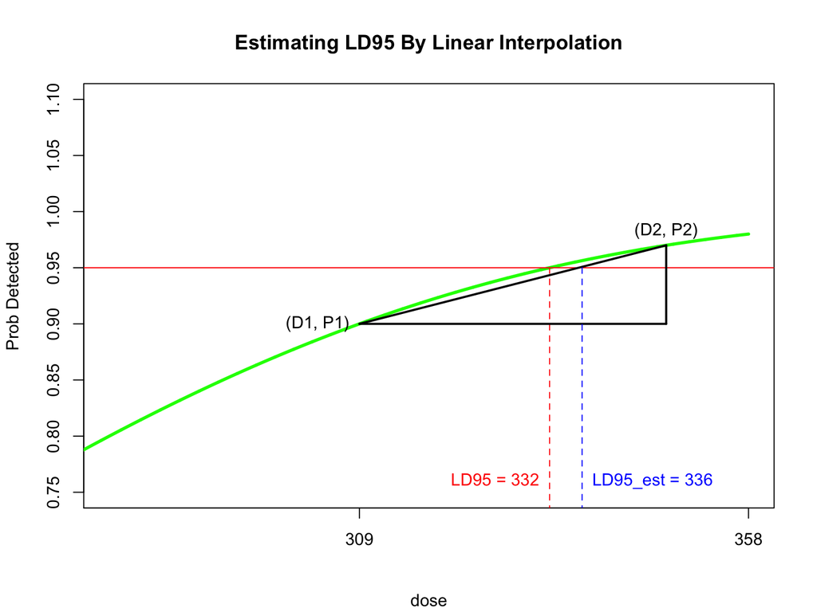

Figure 8: Estimating LD95 By Linear Interpolation

```r
inv_probit <- function(p, m) (qnorm(p) - coef(m)[1])/coef(m)[2]

prob_vec <- c(.1, .2, .5, .9, 0.98)
dose_vec <- inv_probit(prob_vec, full_probit_fit)

full_probit_design <- data.frame(dose=dose_vec, prob=prob_vec)

# initialize plot
plot_model(full_probit_design, model=full_probit_fit, Line=T, Points=F,
   Ylim=c(0.75, 1.1),
   Xlim=c(inv_probit(0.80, full_probit_fit), inv_probit(0.98, full_probit_fit))
  )


# get true_lod
Target <- 0.95 # Targeted hit rate for LoD
true_lod <- inv_probit(Target, full_probit_fit)

# Add dotted line for P=Target
x_pTarget <- inv_probit(Target, full_probit_fit)
segments(x0=x_pTarget, x1=x_pTarget, y0=Target, y1=0, col='red', lty=2)
#segments(x0=1e-7, x1=x_pTarget, y0=Target, y1=Target, col='red', lty=2)
abline(h=Target, col='red')
text(x=x_pTarget, y=0.76, paste0("LD95 = ", round(x_pTarget)), col='red',
   pos=2)

# Add linear interpolation segments
P1 <- 0.90
P2 <- 0.97
D1 <- inv_probit(P1, full_probit_fit)
D2 <- inv_probit(P2, full_probit_fit)

segments(x0=D1, x1=D2, y0=P1, y1=P2, lwd=2)
segments(x0=D1, x1=D2, y0=P1, y1=P1, lwd=2)
segments(x0=D2, x1=D2, y0=P1, y1=P2, lwd=2)


text(D1, .90, "(D1, P1)", pos=2)
text(D2, .97, "(D2, P2)", pos=3)## adj=c(0, 0.5))

LD95_interpol <- D1 + (Target - P1)/(P2-P1) * (D2 - D1)
segments(x0=LD95_interpol, x1=LD95_interpol, y0=Target, y1=0, col='blue', lty=2)
text(x=LD95_interpol, y=0.76, paste0("LD95_est = ", round(LD95_interpol)),
   col='blue', pos=4)


title("Estimating LD95 By Linear Interpolation")
```

**Some notes**:

$$\begin{equation}
var(\frac{X}{Y}) \approx \frac{var(X)}{\mu_Y^2} - \frac{2\mu_X}{\mu_Y^3} cov(X,Y) + \frac{\mu_X^2}{\mu_Y^4}var(Y) \\
= \left( \frac{\mu_X}{\mu_Y} \right)^2 \left( \frac{var(X)}{\mu_X^2} + \frac{var(Y)}{\mu_Y^2}
- 2 \frac{cov(X,Y)}{\mu_X \mu_Y} \right)
\tag{5}
\end{equation}$$

The following table summarizes LoD estimates from 30 simulated replications of these 2-design point data sets for different values of (D1, P1) and (D2, P2).

```r
near_lod_prob_vec <- seq(from=.90,  to=.99, by=.03)

near_lod_dose_vec <- inv_probit(near_lod_prob_vec, full_probit_fit)

near_lod_probit_design <- data.frame(rbind(
 c(P1=0.90, P2=0.98,
   D1=inv_probit(0.90, full_probit_fit)[[1]], D2=inv_probit(0.98, full_probit_fit)[[1]]),
 c(P1=0.92, P2=0.98,
   D1=inv_probit(0.92, full_probit_fit)[[1]], D2=inv_probit(0.98, full_probit_fit)[[1]]),
 c(P1=0.93, P2=0.97,
   D1=inv_probit(0.93, full_probit_fit)[[1]], D2=inv_probit(0.97, full_probit_fit)[[1]])))


set.seed(12379)
Target <- 0.95 # Targeted hit rate for LoD

near_lod_sim_results_frm <- data.frame()

for(RR in 1:nrow(near_lod_probit_design)) {
#print(RR)
  D1 <- near_lod_probit_design[RR,'D1']
  D2 <- near_lod_probit_design[RR,'D2']
  P1 <- near_lod_probit_design[RR,'P1']
  P2 <- near_lod_probit_design[RR,'P2']

 LD95_est_vec <- do.call('c', lapply(1:REP, function(JUNK) {
#print(JUNK)
  D1_sim_data <- rbinom(n=50, size=1, p=P1)
  D2_sim_data <- rbinom(n=50, size=1, p=P2)
  P1_sim <- mean(D1_sim_data)
  P2_sim <- mean(D2_sim_data)

  if(P2_sim <= P1_sim) {
     P1_sim = mean(P1_sim, P2_sim)
     P2_sim = mean(P1_sim, P2_sim)
  }

  if(P1_sim < Target & P2_sim > Target)
  LD95_est <- D1 + (D2 - D1) * (Target - P1_sim)/(P2_sim-P1_sim)  else
  if(max(P1_sim, P2_sim) < Target) LD95_est <- D1 else
  if(min(P1_sim, P2_sim) > Target) LD95_est <- D2 else stop("we should never get here")
  LD95_est
 }))

 near_lod_sim_results_frm <- rbind(near_lod_sim_results_frm,
 data.frame(
  D1=round(D1), D2=round(D2), P1=P1, P2=P2,
  est_mean = round(mean(LD95_est_vec),1),
  est_sd = round(sd(LD95_est_vec),1)))

}
  #q = round(t(quantile(LD95_est_vec, prob=c(1:3/4))))

true_lod <- inv_probit(Target, full_probit_fit)

knitr::kable(
#cat("2 design points simulation results: True LD95 =", round(true_lod), '\n')
near_lod_sim_results_frm,
caption=paste("2 design points simulation results: True LD95 =", round(true_lod))
) %>%
kableExtra::kable_styling(full_width = F)
```

Table 5: 2 design points simulation results: True LD95 = 332

| D1 | D2 | P1 | P2 | est_mean | est_sd |
| --- | --- | --- | --- | --- | --- |
| 309 | 358 | 0.90 | 0.98 | 339.8 | 14.6 |
| 317 | 358 | 0.92 | 0.98 | 344.5 | 11.4 |
| 322 | 347 | 0.93 | 0.97 | 335.1 | 8.4 |

For comparison, recall the characteristcis of LoD estimates from an equivalent probit model analysis:

```r
knitr::kable(
lod_est_var_mtx[1,1:3,drop=F],
caption=paste("Probit fit LoD Estimate Variability: True LoD =",round(true_lod,1))
) %>%
kableExtra::kable_styling(full_width = F)
```

Table 6: Probit fit LoD Estimate Variability: True LoD = 332.2

| N | lod_mean | lod_sd |
| --- | --- | --- |
| 20 | 357.6 | 19 |

# 7 References

CLSI documents on GRAIL shared drive can be accessed [here](https://drive.google.com/drive/folders/0B9btJZT36cFKbm5fZUxlTXZaSEk?resourcekey=0-0_qdmTP58DDJpfqUq-_Vyg).

1.

CLSI. Evaluation of detection capability for clinical laboratory measurement procedures; approved guideline (2012). Second Edition. (CLSI document EP17-A2. Wayne, PA: Clinical; Laboratory Standards Institute).

**R version 4.0.2 (2020-06-22)**

**Platform:** x86_64-apple-darwin17.0 (64-bit)

**locale:** en_US.UTF-8||en_US.UTF-8||en_US.UTF-8||C||en_US.UTF-8||en_US.UTF-8

**attached base packages:** *stats*, *graphics*, *grDevices*, *utils*, *datasets*, *methods* and *base*

**other attached packages:** *magrittr(v.2.0.2)*, *dplyr(v.1.0.8)*, *plyr(v.1.8.6)*, *data.table(v.1.13.0)*, *bookdown(v.0.20.6)*, *knitr(v.1.38)*, *rmarkdown(v.2.9)* and *BiocStyle(v.2.16.1)*

**loaded via a namespace (and not attached):** *Rcpp(v.1.0.5)*, *investr(v.1.4.2)*, *highr(v.0.8)*, *bslib(v.0.2.5.1)*, *compiler(v.4.0.2)*, *pillar(v.1.7.0)*, *BiocManager(v.1.30.16)*, *jquerylib(v.0.1.4)*, *tools(v.4.0.2)*, *digest(v.0.6.27)*, *viridisLite(v.0.3.0)*, *jsonlite(v.1.7.1)*, *evaluate(v.0.15)*, *lifecycle(v.1.0.1)*, *tibble(v.3.1.6)*, *pkgconfig(v.2.0.3)*, *rlang(v.1.0.2)*, *rstudioapi(v.0.13)*, *DBI(v.1.1.0)*, *cli(v.3.2.0)*, *yaml(v.2.2.1)*, *xfun(v.0.30)*, *fastmap(v.1.1.0)*, *kableExtra(v.1.2.1)*, *xml2(v.1.3.2)*, *httr(v.1.4.2)*, *stringr(v.1.4.0)*, *generics(v.0.0.2)*, *vctrs(v.0.3.8)*, *sass(v.0.4.0)*, *webshot(v.0.5.2)*, *tidyselect(v.1.1.2)*, *glue(v.1.6.2)*, *R6(v.2.4.1)*, *fansi(v.0.4.1)*, *pander(v.0.6.3)*, *blob(v.1.2.1)*, *purrr(v.0.3.4)*, *scales(v.1.1.1)*, *htmltools(v.0.5.2)*, *ellipsis(v.0.3.2)*, *rvest(v.0.3.6)*, *assertthat(v.0.2.1)*, *colorspace(v.1.4-1)*, *utf8(v.1.1.4)*, *stringi(v.1.5.3)*, *munsell(v.0.5.0)* and *crayon(v.1.4.1)*